# Stan Tutorial

Alex Knudson

3/10/2021

```r
# box loads specific packages+functions into the namespace (similar to Python's import)
box::use(
  rstan[...],
  rstanarm[stan_glm, normal],
  dplyr[...],
  tidyr[...],
  ggplot2[...],
  bayesplot[...],
  magrittr[`%>%`]
)

# rstan has a startup message recommending to set these two options
options(mc.cores = parallel::detectCores())
rstan_options(auto_write = TRUE)
```

# Intro to Bayes

- What is the most likely distribution of a parameter given the data and prior knowledge (or beliefs)
- The posterior is proportional to the prior times the likelihood
- $\mathrm{posterior} \propto \mathrm{prior} \times \mathrm{likelihood}$
- $\pi(\theta | \mathrm{data}) \propto \pi(\theta) \times \pi(\mathrm{data} | \theta)$
- The denominator in Bayes’ Theorem is often too complex to solve analytically
  - Approximation techniques like Markov Chain Monte Carlo (MCMC) are used to estimate the denominator
  - Smarter sampling can be done to draw samples directly from the posterior

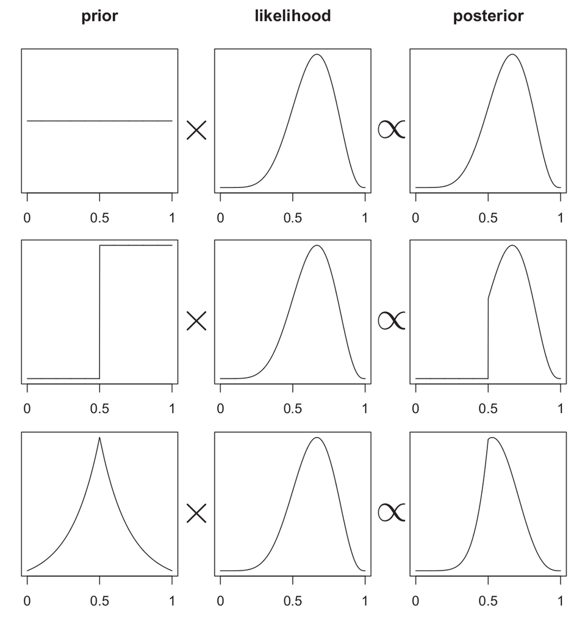

The posterior distribution as a product of the prior distribution times the likelihood. Image from Statistical Rethinking by Richard McElreath.

## Basics of Hamiltonian Monte Carlo

- A massless particle is imparted with random velocity (speed + direction)
- http://chi-feng.github.io/mcmc-demo/app.html
- Adaptive parameters are learned during the warmup sampling phase
  - step size, momentum
- Compared to Gibbs Sampling
  - HMC generally has reduced autocorrelation between successive samples
  - All parameters are updated at the same time
  - The “warmup” period is not “burn-in”
  - Divergent transitions for diagnostics
  - Stan complains more, which is a good thing

## Limitations of HMC

- simulating the path of a particle requires smooth gradients

# Simple Linear Regression

The simplest linear regression model is the following, with a single predictor and a slope and intercept coefficient, and normally distributed noise. This model can be written using standard regression notation as

$$y = \alpha + \beta x + \epsilon \quad \mathrm{where} \quad \epsilon \sim \mathcal{N}(0, \sigma)$$

We can re-write the above in an equivalent form

$$y - (\alpha + \beta x) \sim \mathcal{N}(0, \sigma) \Longleftrightarrow y \sim \mathcal{N}(\alpha + \beta x, \sigma)$$

## Data

```r
load("../data/simple_linear_model.rda")
str(simple_linear_model)
```

```
'data.frame':   30 obs. of  2 variables:
 $ x: num  0.4595 -1.2636 -0.215 1.5681 -0.0729 ...
 $ y: num  2.88 -2.53 1.61 5.59 1.87 ...
```

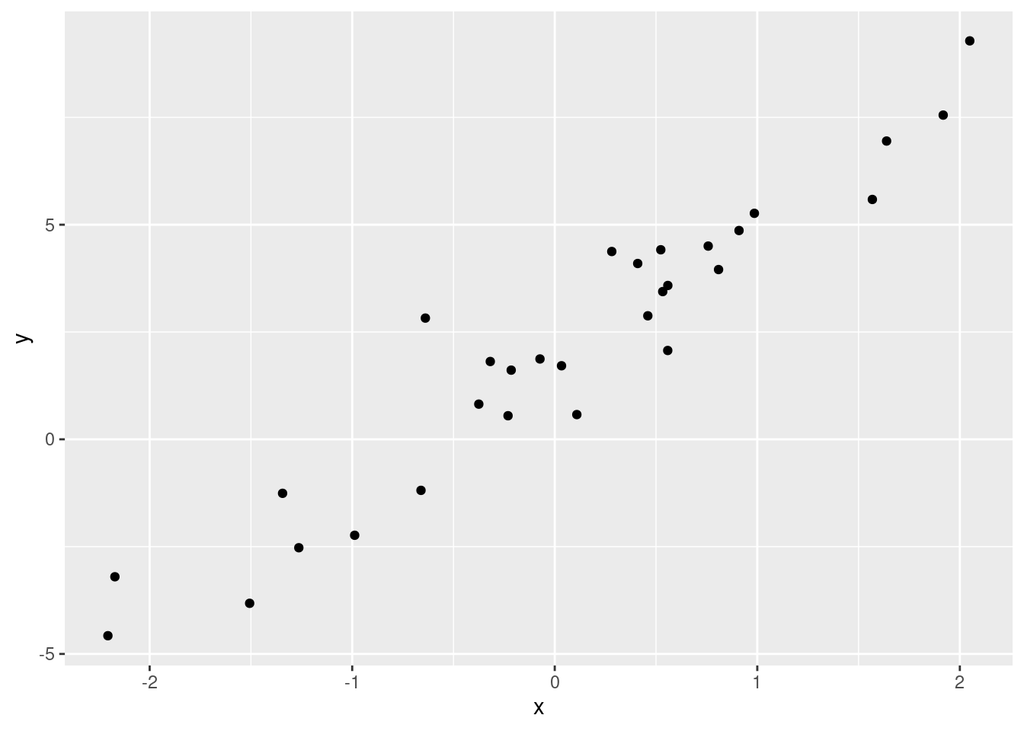

```r
ggplot(simple_linear_model, aes(x, y)) +
  geom_point()
```

## Model Fitting

### Frequentist

```r
lm(y ~ 1 + x, data = simple_linear_model) %>%
  summary()
```

```
Call:
lm(formula = y ~ 1 + x, data = simple_linear_model)

Residuals:
    Min      1Q  Median      3Q     Max
-1.7320 -0.6748 -0.0128  0.6600  2.7456

Coefficients:
            Estimate Std. Error t value Pr(>|t|)
(Intercept)   1.9831     0.1869   10.61 2.55e-11 ***
x             2.9819     0.1727   17.27  < 2e-16 ***
---
Signif. codes:  0 '***' 0.001 '**' 0.01 '*' 0.05 '.' 0.1 ' ' 1

Residual standard error: 1.021 on 28 degrees of freedom
Multiple R-squared:  0.9141,    Adjusted R-squared:  0.9111
F-statistic: 298.1 on 1 and 28 DF,  p-value: < 2.2e-16
```

- We get an estimate for each parameter
- We get the standard error in the estimates
- *Confidence* intervals can be constructed

### Bayesian using `rstanarm`

`rstanarm` is an easy to use replacement for standard `R`’s `lm` and `glm`. It uses pre-compiled Stan programs in the backend, so it is fast to use and fast to sample.

**Setting weakly informative priors manually**

```r
slm <- stan_glm(y ~ 1 + x, family = gaussian(link = "identity"),
                data = simple_linear_model,
                prior = normal(0, 1),
                prior_intercept = normal(0, 1),
                # set refresh=0 to hide sampling progress
                refresh = 100)

summary(object = slm, digits = 3)
```

```
Model Info:
 function:     stan_glm
 family:       gaussian [identity]
 formula:      y ~ 1 + x
 algorithm:    sampling
 sample:       4000 (posterior sample size)
 priors:       see help('prior_summary')
 observations: 30
 predictors:   2

Estimates:
              mean   sd    10%   50%   90%
(Intercept) 1.908  0.199 1.652 1.916 2.151
x           2.885  0.181 2.650 2.890 3.111
sigma       1.070  0.150 0.894 1.053 1.272

Fit Diagnostics:
           mean   sd    10%   50%   90%
mean_PPD 2.106  0.277 1.747 2.109 2.452

The mean_ppd is the sample average posterior predictive distribution of the outcome variable (for details see help('summary.stanreg')).

MCMC diagnostics
              mcse  Rhat  n_eff
(Intercept)   0.004 0.999 3172
x             0.003 1.000 3466
sigma         0.003 1.000 3021
mean_PPD      0.005 1.000 3548
log-posterior 0.032 1.004 1633

For each parameter, mcse is Monte Carlo standard error, n_eff is a crude measure of effective sample size, and Rhat is the potential scale reduction factor on split chains (at convergence Rhat=1).
```

- Get an estimate for each parameter
- Get standard deviations of the posterior distribution for each parameter
- Have posterior samples to construct *credible* intervals

```r
post <- as.data.frame(slm)
str(post)
```

```
'data.frame':   4000 obs. of  3 variables:
 $ (Intercept): num  1.85 1.85 1.93 1.92 1.82 ...
 $ x          : num  3.2 3.23 3.3 2.59 2.87 ...
 $ sigma      : num  1.126 1.141 1.172 0.896 1.008 ...
```

- Can use the posterior samples to construct all kinds of summary stats
  - median
  - highest density posterior intervals

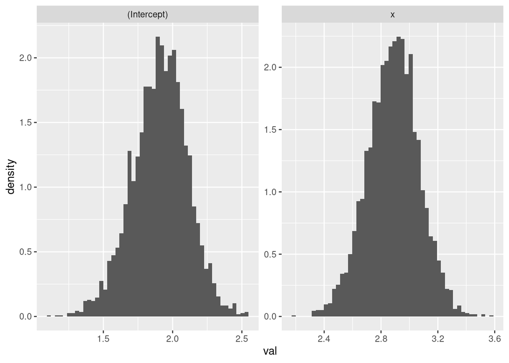

```r
post %>%
  select(`(Intercept)`, x) %>%
  pivot_longer(all_of(1:2), names_to = "par", values_to = "val") %>%
  mutate(par = factor(par)) %>%
  ggplot(aes(val, ..density..)) +
  geom_histogram(bins=50) +
  facet_wrap(~ par, scales = "free")
```

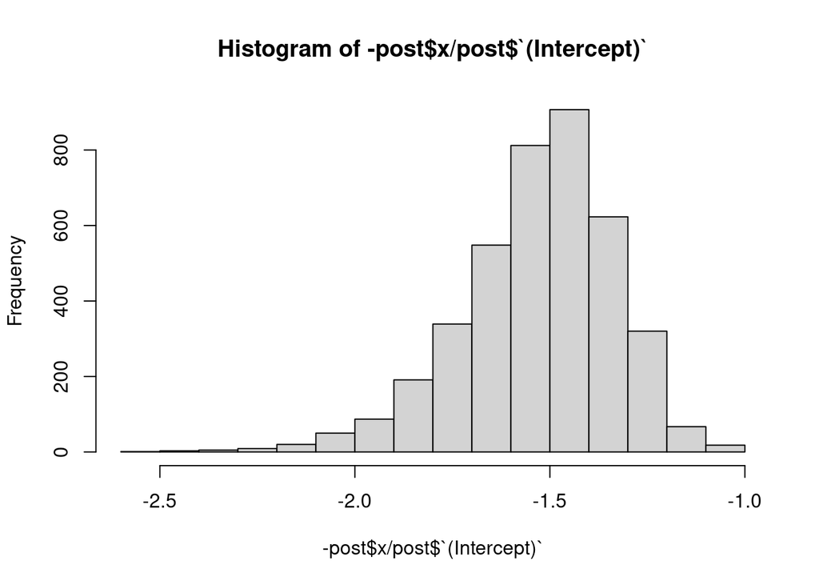

```r
hist(-post$x / post$`(Intercept)`)
```

- Can use the posterior to plot a handful of sample curves

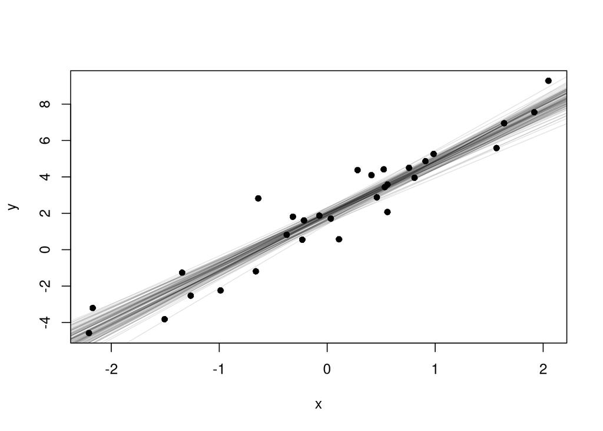

```r
n <- 100
idx <- sample(1:nrow(post), size = n, replace = TRUE)
a <- post$`(Intercept)`[idx]
b <- post$x[idx]

plot(y ~ x, pch = 16, data = simple_linear_model)
for (i in 1:n) {
  abline(a = a[i], b = b[i], col = rgb(0,0,0,0.1))
}
```

**setting more informative priors**

```r
# Not run
stan_glm(y ~ x, family = gaussian(link = "identity"),
         data = simple_linear_model,
         prior = normal(2, 1),
         prior_intercept = normal(1, 1),
         refresh = 0)
```

**Letting Stan adaptively set priors and transform data**

```r
# Not run
stan_glm(y ~ x, family = gaussian(link = "identity"),
         data = simple_linear_model,
         refresh = 0)
```

### Bayesian using Stan (`rstan`)

**Writing the model**

- three essential “blocks” to every Stan program
  - data
  - parameters
  - model
- other blocks
  - functions
  - transformed data
  - transformed parameters
  - generated quantities
- full details: https://mc-stan.org/docs/2_26/reference-manual/blocks-chapter.html
- Can implement “robust” regression
  - error terms don’t need to be assumed to be normally distributed
  - can use student-T

```stan
data {
  int N;       // number of observations
  vector[N] y; // outcome
  vector[N] x; // predictor
}

parameters {
  real intercept;
  real slope;
  real<lower=0> sigma;
}

model {
  // Priors
  intercept ~ normal(0, 1);
  slope ~ normal(0, 1);
  sigma ~ exponential(1);

  // Likelihood
  y ~ normal(intercept + slope*x, sigma);
}
```

**Preparing the Data**

```r
dat <- list(
  N = nrow(simple_linear_model),
  x = simple_linear_model$x,
  y = simple_linear_model$y
)
```

**Running the Model**

```r
stan_lm_fit <- sampling(slm_stan, data = dat)
```

**Extracting samples**

```r
lm_post <- rstan::extract(stan_lm_fit)
str(lm_post)
```

```
List of 4
 $ intercept: num [1:4000(1d)] 2.02 1.64 1.86 2.03 1.96 ...
  ..- attr(*, "dimnames")=List of 1
  .. ..$ iterations: NULL
 $ slope    : num [1:4000(1d)] 2.87 2.87 3.26 2.83 2.82 ...
  ..- attr(*, "dimnames")=List of 1
  .. ..$ iterations: NULL
 $ sigma    : num [1:4000(1d)] 1.116 1.051 1.059 1.02 0.814 ...
  ..- attr(*, "dimnames")=List of 1
  .. ..$ iterations: NULL
 $ lp__     : num [1:4000(1d)] -22.4 -23 -24.1 -22.1 -23.5 ...
  ..- attr(*, "dimnames")=List of 1
  .. ..$ iterations: NULL
```

# Real-world data: New York Air Quality

```r
data("airquality")
str(airquality)
```

```
'data.frame':   153 obs. of  6 variables:
 $ Ozone  : int  41 36 12 18 NA 28 23 19 8 NA ...
 $ Solar.R: int  190 118 149 313 NA NA 299 99 19 194 ...
 $ Wind   : num  7.4 8 12.6 11.5 14.3 14.9 8.6 13.8 20.1 8.6 ...
 $ Temp   : int  67 72 74 62 56 66 65 59 61 69 ...
 $ Month  : int  5 5 5 5 5 5 5 5 5 5 ...
 $ Day    : int  1 2 3 4 5 6 7 8 9 10 ...
```

**Prepare Data**

```r
dat <- airquality %>%
  select(Ozone, Temp) %>%
  drop_na()

str(dat)
```

```
'data.frame':   116 obs. of  2 variables:
 $ Ozone: int  41 36 12 18 28 23 19 8 7 16 ...
 $ Temp : int  67 72 74 62 66 65 59 61 74 69 ...
```

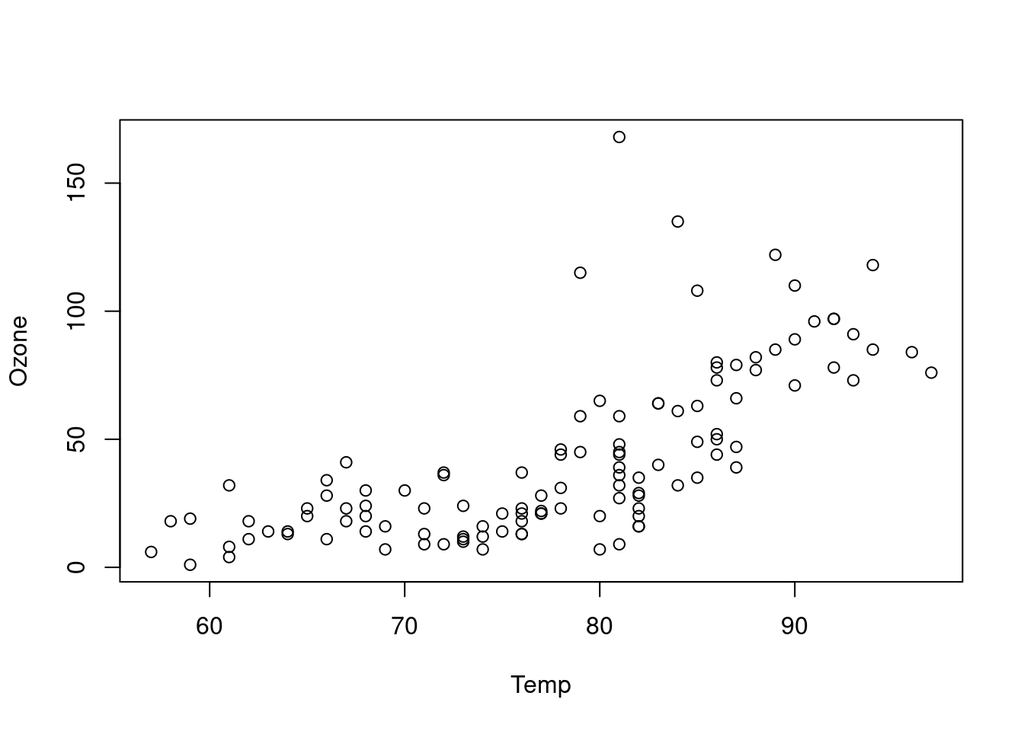

```r
plot(Ozone ~ Temp, data = dat)
```

### Frequentist

```r
glm(Ozone ~ 1 + Temp, data = dat,
    family = poisson(link = "log")) %>% summary()
```

```
Call:
glm(formula = Ozone ~ 1 + Temp, family = poisson(link = "log"),
    data = dat)

Deviance Residuals:
   Min      1Q  Median      3Q     Max
-6.534  -2.458  -0.702   1.499  14.345

Coefficients:
             Estimate Std. Error z value Pr(>|z|)
(Intercept) -1.436089   0.143356  -10.02   <2e-16 ***
Temp         0.064268   0.001718   37.40   <2e-16 ***
---
Signif. codes:  0 '***' 0.001 '**' 0.01 '*' 0.05 '.' 0.1 ' ' 1

(Dispersion parameter for poisson family taken to be 1)

    Null deviance: 2714.8  on 115  degrees of freedom
Residual deviance: 1168.1  on 114  degrees of freedom
AIC: 1782.8

Number of Fisher Scoring iterations: 5
```

### Bayes using `rstanarm`

```r
prm <- stan_glm(Ozone ~ 1 + Temp, data = dat,
                family = poisson(link = "log"))

summary(object = prm, digits = 3)
```

```
Model Info:
 function:     stan_glm
 family:       poisson [log]
 formula:      Ozone ~ 1 + Temp
 algorithm:    sampling
 sample:       4000 (posterior sample size)
 priors:       see help('prior_summary')
 observations: 116
 predictors:   2

Estimates:
              mean   sd     10%    50%    90%
(Intercept) -1.446  0.146 -1.635 -1.445 -1.265
Temp         0.064  0.002  0.062  0.064  0.067

Fit Diagnostics:
           mean   sd     10%    50%    90%
mean_PPD 42.096  0.857 41.000 42.086 43.216

The mean_ppd is the sample average posterior predictive distribution of the outcome variable (for details see help('summary.stanreg')).

MCMC diagnostics
              mcse  Rhat  n_eff
(Intercept)   0.004 1.002 1599
Temp          0.000 1.002 1643
mean_PPD      0.016 1.000 2992
log-posterior 0.029 1.001 1369

For each parameter, mcse is Monte Carlo standard error, n_eff is a crude measure of effective sample size, and Rhat is the potential scale reduction factor on split chains (at convergence Rhat=1).
```

### Bayes using `rstan`

> Poisson regression assumes the response variable Y has a Poisson distribution, and assumes the logarithm of its expected value can be modeled by a linear combination of unknown parameters.

$$\begin{align}
Ozone &\sim \mathrm{Poisson}(\lambda) \\
\log(\lambda) &= \alpha + \beta \cdot Temp
\end{align}$$

**Writing the program**

```stan
data {
  int N;
  vector[N] Temp;
  int Ozone[N];
}

parameters {
  real a;
  real b;
}

model {
  // Priors
  a ~ normal(0, 100);
  b ~ normal(0, 100);

  // likelihood
  Ozone ~ poisson_log(a + b*Temp);
}
```

**Preparing the Data**

```r
dat_aq <- list(
  N = nrow(dat),
  Temp = as.numeric(dat$Temp),
  Ozone = as.integer(dat$Ozone)
)
```

**Running the Model**

```r
stan_poiss_fit <- sampling(poisson_stan, data = dat_aq,
                           cores = 4, refresh = 0)
```

**Extracting samples**

```r
poiss_post <- rstan::extract(stan_poiss_fit)
str(poiss_post)
```

```
List of 3
 $ a   : num [1:4000(1d)] -1.42 -1.67 -1.6 -1.44 -1.48 ...
  ..- attr(*, "dimnames")=List of 1
  .. ..$ iterations: NULL
 $ b   : num [1:4000(1d)] 0.0642 0.0671 0.0666 0.0643 0.0645 ...
  ..- attr(*, "dimnames")=List of 1
  .. ..$ iterations: NULL
 $ lp__: num [1:4000(1d)] 14167 14166 14163 14167 14167 ...
  ..- attr(*, "dimnames")=List of 1
  .. ..$ iterations: NULL
```

# Further Resources

- Excellent textbook: Statistical Rethinking 2nd Edition by Richard McElreath
  - Lecture videos: https://www.youtube.com/playlist?list=PLDcUM9US4XdNM4Edgs7weiyIguLSToZRI
  - Lecture homework: https://github.com/rmcelreath/stat_rethinking_2020
  - Corresponding R package: https://github.com/rmcelreath/rethinking/
- Stan Documentation
  - Reference manual: https://mc-stan.org/docs/2_26/reference-manual/index.html
  - User’s guide: https://mc-stan.org/docs/2_26/stan-users-guide/index.html
- In depth tutorial
  - *Towards a Principled Bayesian Workflow*, by Michael Betancourt
  - https://betanalpha.github.io/assets/case_studies/principled_bayesian_workflow.html
- Anything by Andrew Gelmen